# Classification with Decision Trees and k-Nearest Neighbors — MASS::biopsy

Aminur Refat Faisal

2026-08-20

# 1. Overview

This notebook re-runs the **complete supervised classification pipeline** from the `iris` version of this notebook, but this time on R’s built-in **`MASS::biopsy`** dataset — a **binary, medical-diagnosis** classification problem (benign vs. malignant breast tumors) with **9 numeric, fairly correlated features** instead of iris’s 4. The goal is to see how a **Decision Tree** and **k-Nearest Neighbors (KNN)** behave when: (a) there are only two classes instead of three, (b) the features are more numerous and more correlated with each other, and (c) the raw data actually contains missing values that must be handled before modeling.

The pipeline still has 9 stages:

1. **Load & explore data** — inspect structure, summary statistics, missing values, and class balance.
2. **Visualize relationships** — pairwise scatterplots, boxplots by class, and a correlation heatmap.
3. **Preprocess** — drop the ID column, handle missing values, and split into train/test sets.
4. **Decision Tree — model building** — fit a classification tree with `rpart`.
5. **Decision Tree — visualization & pruning** — plot the tree and control overfitting via the complexity parameter.
6. **Decision Tree — evaluation** — confusion matrix, accuracy, sensitivity/specificity, variable importance.
7. **KNN — preprocessing & model building** — scale features (required for KNN) and fit models across a range of *k*.
8. **KNN — evaluation** — confusion matrix, accuracy, and an accuracy-vs-*k* curve to select the best *k*.
9. **Model comparison, ROC/AUC, and save outputs** — compare both models side by side and export results.

> **Why this matters:** With `iris`, both algorithms achieved near-perfect accuracy because the petal measurements separated the three species almost perfectly. `biopsy` is a tougher, more realistic test: 9 correlated features, a real (if small) amount of missing data, and — because this is a medical-diagnosis task — the **cost of errors is asymmetric**. Missing a malignant tumor (a false negative) is far more dangerous than flagging a benign one for a second look (a false positive), so beyond plain accuracy we also look at **sensitivity for the malignant class** below.

# 2. Packages

```r
# List of required packages
packages <- c("tidyverse", "caret", "rpart", "rpart.plot",
              "class", "GGally", "e1071", "MASS", "pROC")

# Check which packages are already installed on this machine
installed_packages <- rownames(installed.packages())

for (pkg in packages) {
  # Install only if missing
  if (!(pkg %in% installed_packages)) {
    install.packages(pkg, dependencies = TRUE)
  }
  # Load the package into the current session
  library(pkg, character.only = TRUE)
}

# NOTE: MASS::select() and dplyr::select() clash. We load MASS only for its
# `biopsy` dataset and always call dplyr's version explicitly as
# dplyr::select() further down, to avoid silently masking tidyverse verbs.

# Fix the random seed everywhere in this notebook so that the train/test
# split, tree fitting (which has some randomness in tie-breaking), and KNN
# results are exactly reproducible on re-run.
set.seed(42)
```

# 3. The Dataset: `MASS::biopsy`

`biopsy` is one of R’s built-in datasets (no download needed — just type `data(biopsy)`). It contains **699 fine-needle-aspirate biopsy samples** from the Wisconsin Breast Cancer study, each described by **9 cytological characteristics** scored on a 1–10 scale, with a binary outcome: whether the tumor was ultimately diagnosed as **benign** or **malignant**. Unlike `iris`, this dataset has (a) only two classes, (b) noticeably correlated features (several attributes co-vary with how abnormal a cell looks overall), and (c) a small amount of real missing data — a good stress test for a pipeline built on clean data.

```r
data(biopsy)

# ---- Basic structure ----
str(biopsy)
```

```
## 'data.frame':    699 obs. of  11 variables:
##  $ ID   : chr  "1000025" "1002945" "1015425" "1016277" ...
##  $ V1   : int  5 5 3 6 4 8 1 2 2 4 ...
##  $ V2   : int  1 4 1 8 1 10 1 1 1 2 ...
##  $ V3   : int  1 4 1 8 1 10 1 2 1 1 ...
##  $ V4   : int  1 5 1 1 3 8 1 1 1 1 ...
##  $ V5   : int  2 7 2 3 2 7 2 2 2 2 ...
##  $ V6   : int  1 10 2 4 1 10 10 1 1 1 ...
##  $ V7   : int  3 3 3 3 3 9 3 3 1 2 ...
##  $ V8   : int  1 2 1 7 1 7 1 1 1 1 ...
##  $ V9   : int  1 1 1 1 1 1 1 1 5 1 ...
##  $ class: Factor w/ 2 levels "benign","malignant": 1 1 1 1 1 2 1 1 1 1 ...
```

```r
# ---- Summary statistics per numeric column ----
summary(biopsy)
```

```
##          ID            V1               V2               V3
##  Length   :699   Min.   : 1.000   Min.   : 1.000   Min.   : 1.000
##  N.unique :645   1st Qu.: 2.000   1st Qu.: 1.000   1st Qu.: 1.000
##  N.blank  :  0   Median : 4.000   Median : 1.000   Median : 1.000
##  Min.nchar:  5   Mean   : 4.418   Mean   : 3.134   Mean   : 3.207
##  Max.nchar:  8   3rd Qu.: 6.000   3rd Qu.: 5.000   3rd Qu.: 5.000
##                  Max.   :10.000   Max.   :10.000   Max.   :10.000
##
##        V4               V5               V6               V7
##  Min.   : 1.000   Min.   : 1.000   Min.   : 1.000   Min.   : 1.000
##  1st Qu.: 1.000   1st Qu.: 2.000   1st Qu.: 1.000   1st Qu.: 2.000
##  Median : 1.000   Median : 2.000   Median : 1.000   Median : 3.000
##  Mean   : 2.807   Mean   : 3.216   Mean   : 3.545   Mean   : 3.438
##  3rd Qu.: 4.000   3rd Qu.: 4.000   3rd Qu.: 6.000   3rd Qu.: 5.000
##  Max.   :10.000   Max.   :10.000   Max.   :10.000   Max.   :10.000
##                                    NAs    :16
##        V8               V9               class
##  Min.   : 1.000   Min.   : 1.000   benign   :458
##  1st Qu.: 1.000   1st Qu.: 1.000   malignant:241
##  Median : 1.000   Median : 1.000
##  Mean   : 2.867   Mean   : 1.589
##  3rd Qu.: 4.000   3rd Qu.: 1.000
##  Max.   :10.000   Max.   :10.000
##
```

```r
# ---- Class balance: is this a balanced classification problem? ----
table(biopsy$class)
```

```
##
##    benign malignant
##       458       241
```

**Variables:**

| Column | Type | Description |
| --- | --- | --- |
| `ID` | character | Sample code number — **identifier only, not a predictive feature** |
| `V1` | numeric (1–10) | Clump Thickness |
| `V2` | numeric (1–10) | Uniformity of Cell Size |
| `V3` | numeric (1–10) | Uniformity of Cell Shape |
| `V4` | numeric (1–10) | Marginal Adhesion |
| `V5` | numeric (1–10) | Single Epithelial Cell Size |
| `V6` | numeric (1–10) | Bare Nuclei (contains missing values) |
| `V7` | numeric (1–10) | Bland Chromatin |
| `V8` | numeric (1–10) | Normal Nucleoli |
| `V9` | numeric (1–10) | Mitoses |
| `class` | factor (2 levels) | **Target variable** — benign / malignant |

```r
# Always check for missing values before modeling — neither rpart nor knn()
# handles NAs gracefully by default. Unlike iris, biopsy actually has some.
cat("Total missing values:", sum(is.na(biopsy)), "\n")
```

```
## Total missing values: 16
```

```r
colSums(is.na(biopsy))
```

```
##    ID    V1    V2    V3    V4    V5    V6    V7    V8    V9 class
##     0     0     0     0     0     0    16     0     0     0     0
```

`V6` (Bare Nuclei) has missing values. We drop the `ID` column (it carries no predictive information) and drop rows with missing `V6`, since it’s a small fraction of the data and neither `rpart` nor `knn()` can use rows with NAs in a predictor out of the box.

```r
biopsy_clean <- biopsy %>%
  dplyr::select(-ID) %>%
  drop_na()

cat("Rows before cleaning:", nrow(biopsy), "\n")
```

```
## Rows before cleaning: 699
```

```r
cat("Rows after cleaning: ", nrow(biopsy_clean), "\n")
```

```
## Rows after cleaning:  683
```

```r
cat("\nClass balance after cleaning:\n")
```

```
##
## Class balance after cleaning:
```

```r
print(table(biopsy_clean$class))
```

```
##
##    benign malignant
##       444       239
```

# 4. Exploratory Visualization

Before modeling, it helps to *see* how separable the classes are and how correlated the features are with each other.

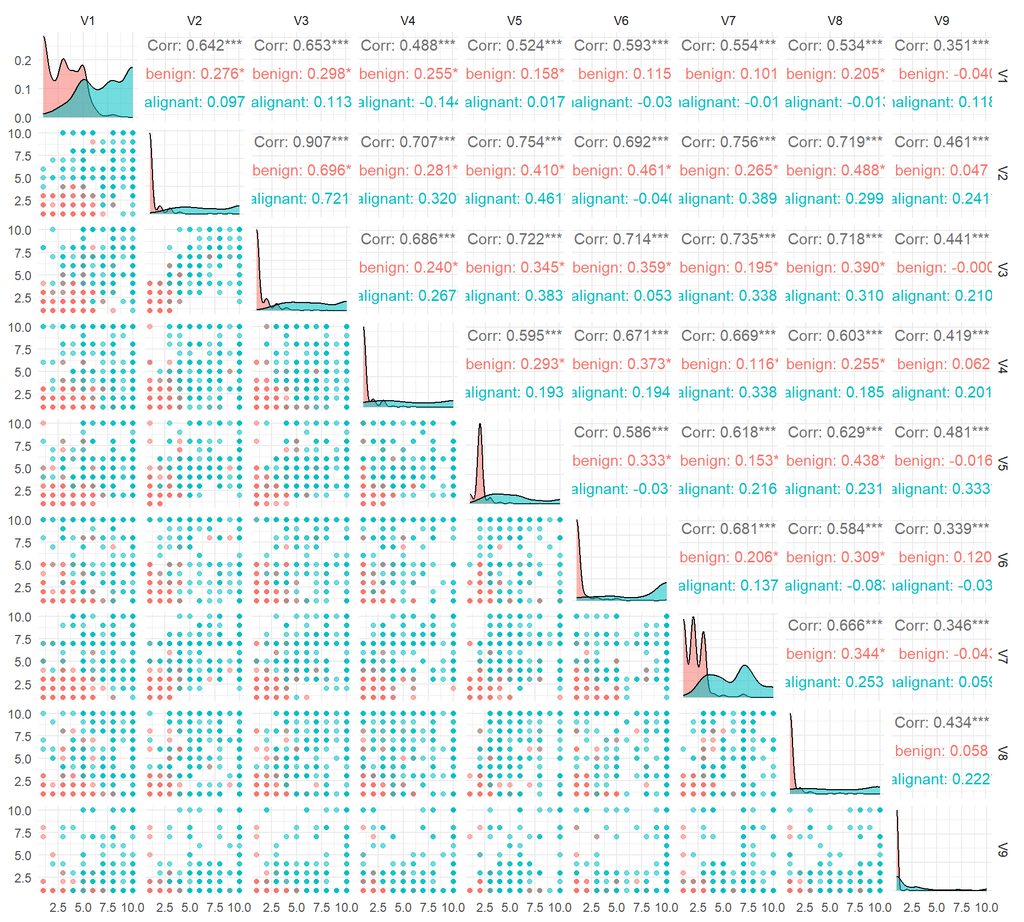

```r
# ggpairs() draws every pairwise combination of the 9 numeric features,
# colored by class, plus per-feature density plots on the diagonal.
# With 9 features this grid is larger (and slower to render) than iris's —
# that density is itself the point: these features are far more numerous
# and correlated than iris's 4.
GGally::ggpairs(
  biopsy_clean,
  columns = 1:9,
  aes(color = class, alpha = 0.6)
) +
  theme_minimal()
```

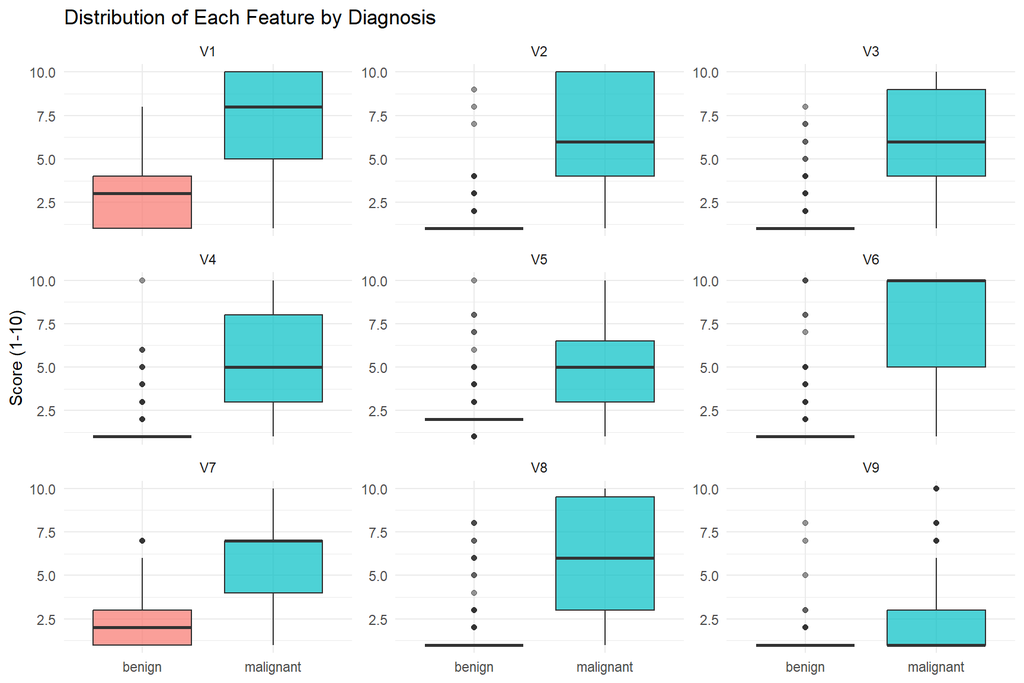

```r
# Reshape to long format so all 9 features can be faceted in one ggplot call
biopsy_long <- biopsy_clean %>%
  pivot_longer(cols = -class, names_to = "Feature", values_to = "Value")

ggplot(biopsy_long, aes(x = class, y = Value, fill = class)) +
  geom_boxplot(alpha = 0.7, outlier.alpha = 0.5) +
  facet_wrap(~ Feature, scales = "free_y") +
  labs(title = "Distribution of Each Feature by Diagnosis",
       x = NULL, y = "Score (1-10)") +
  theme_minimal() +
  theme(legend.position = "none")
```

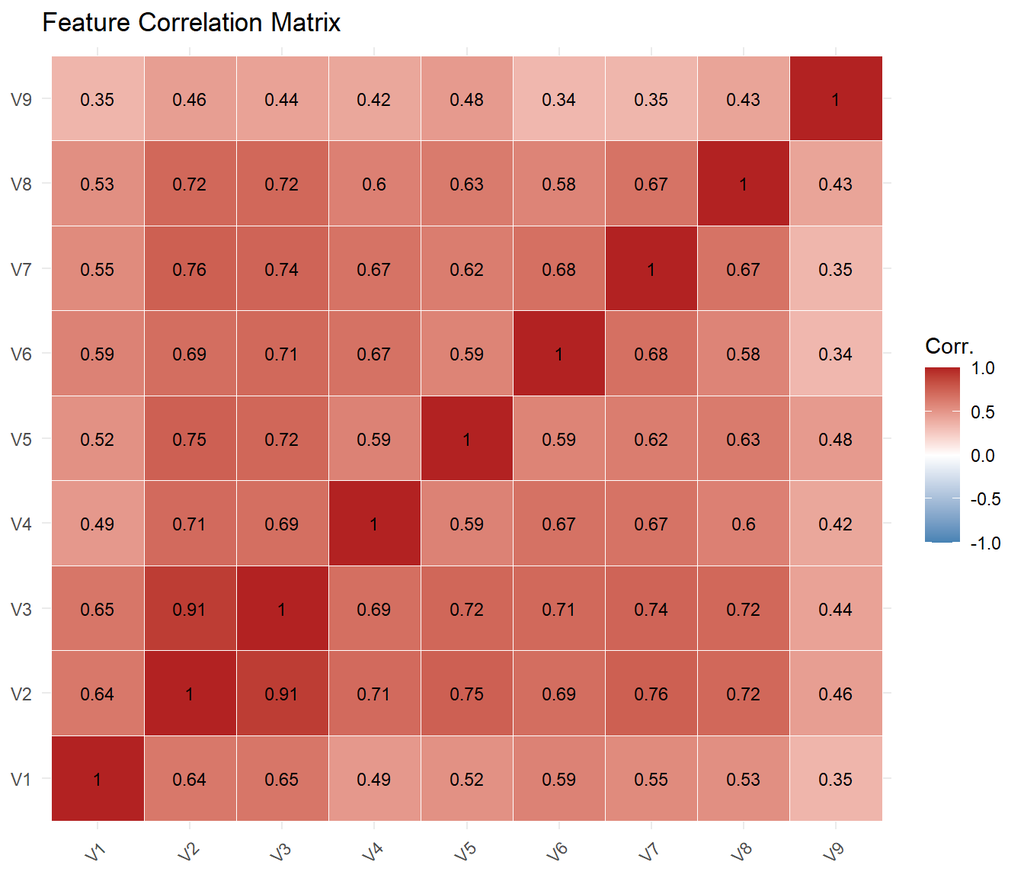

```r
# A correlation heatmap makes the "many correlated numeric features" aspect
# of this dataset explicit, which iris's 4 loosely-related measurements
# didn't really show.
cor_matrix <- biopsy_clean %>%
  dplyr::select(-class) %>%
  cor()

cor_df <- as.data.frame(as.table(cor_matrix))

ggplot(cor_df, aes(x = Var1, y = Var2, fill = Freq)) +
  geom_tile(color = "white") +
  geom_text(aes(label = round(Freq, 2)), size = 3) +
  scale_fill_gradient2(low = "steelblue", mid = "white", high = "firebrick",
                        midpoint = 0, limits = c(-1, 1), name = "Corr.") +
  labs(title = "Feature Correlation Matrix", x = NULL, y = NULL) +
  theme_minimal() +
  theme(axis.text.x = element_text(angle = 45, hjust = 1))
```

> **What to notice:** every single feature separates benign from malignant to some degree (malignant samples score higher on essentially all 9 characteristics), which is different from iris, where two features (sepal measurements) were nearly useless. But the correlation heatmap also shows that many of these features are **strongly correlated with one another** (e.g., `V2`/`V3`, cell size and shape uniformity) — redundant information that a tree can exploit for a compact model, but that adds noise-free “extra” dimensions for KNN’s distance calculation.

# 5. Preprocessing: Train/Test Split

We hold out part of the data to **evaluate generalization** — i.e., how well the model performs on biopsies it has never seen, not just the ones it was fit on.

```r
# createDataPartition() performs STRATIFIED sampling: it preserves the
# original class proportions in both the train and test sets, which matters
# here since biopsy's classes are imbalanced (~65% benign / ~35% malignant)
# and a naive random split could distort that further by chance.
train_index <- createDataPartition(biopsy_clean$class, p = 0.70, list = FALSE)

train_data <- biopsy_clean[train_index, ]
test_data  <- biopsy_clean[-train_index, ]

cat("Training rows:", nrow(train_data), "\n")
```

```
## Training rows: 479
```

```r
cat("Testing rows: ", nrow(test_data), "\n")
```

```
## Testing rows:  204
```

```r
# Confirm the class balance was preserved in both sets
cat("\nTraining set class balance:\n")
```

```
##
## Training set class balance:
```

```r
print(table(train_data$class))
```

```
##
##    benign malignant
##       311       168
```

```r
cat("\nTest set class balance:\n")
```

```
##
## Test set class balance:
```

```r
print(table(test_data$class))
```

```
##
##    benign malignant
##       133        71
```

> **Note on scaling:** as with iris, decision trees split on one feature at a time using threshold rules, so feature scale doesn’t affect the tree’s structure — no scaling is needed for Section 6. KNN still needs scaling for Section 8, even though every `biopsy` feature already lives on the same 1–10 scale — features with more spread would otherwise still dominate the Euclidean distance.

# 6. Decision Tree — Model Building

```r
# method = "class" tells rpart this is a classification (not regression) tree.
tree_model <- rpart(
  class ~ V1 + V2 + V3 + V4 + V5 + V6 + V7 + V8 + V9,
  data = train_data,
  method = "class"
)

# A text summary of the fitted tree: each node shows the split rule,
# number of observations, misclassifications, and predicted class.
print(tree_model)
```

```
## n= 479
##
## node), split, n, loss, yval, (yprob)
##       * denotes terminal node
##
## 1) root 479 168 benign (0.64926931 0.35073069)
##   2) V2< 2.5 293   9 benign (0.96928328 0.03071672) *
##   3) V2>=2.5 186  27 malignant (0.14516129 0.85483871)
##     6) V3< 2.5 15   2 benign (0.86666667 0.13333333) *
##     7) V3>=2.5 171  14 malignant (0.08187135 0.91812865) *
```

## 6.1 Visualizing the Tree

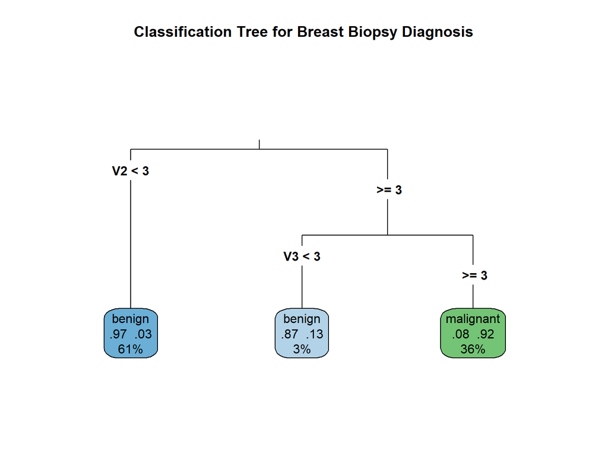

```r
rpart.plot(
  tree_model,
  type = 3, extra = 104, fallen.leaves = TRUE,
  main = "Classification Tree for Breast Biopsy Diagnosis",
  box.palette = "auto"
)
```

## 6.2 Variable Importance

```r
# Higher = more influential in the tree's decisions. Because several
# features are correlated (Section 4), expect the top few to dominate while
# some correlated "duplicates" score lower — the tree only needs one of a
# correlated pair to make an equally good split.
tree_model$variable.importance
```

```
##       V2       V3       V5       V8       V6       V7
## 154.5461 139.9592 113.0014 110.5088 106.3543 104.2370
```

# 7. Decision Tree — Pruning

```r
printcp(tree_model)
```

```
##
## Classification tree:
## rpart(formula = class ~ V1 + V2 + V3 + V4 + V5 + V6 + V7 + V8 +
##     V9, data = train_data, method = "class")
##
## Variables actually used in tree construction:
## [1] V2 V3
##
## Root node error: 168/479 = 0.35073
##
## n= 479
##
##         CP nsplit rel error  xerror     xstd
## 1 0.785714      0   1.00000 1.00000 0.062167
## 2 0.065476      1   0.21429 0.27976 0.038754
## 3 0.010000      2   0.14881 0.17262 0.031069
```

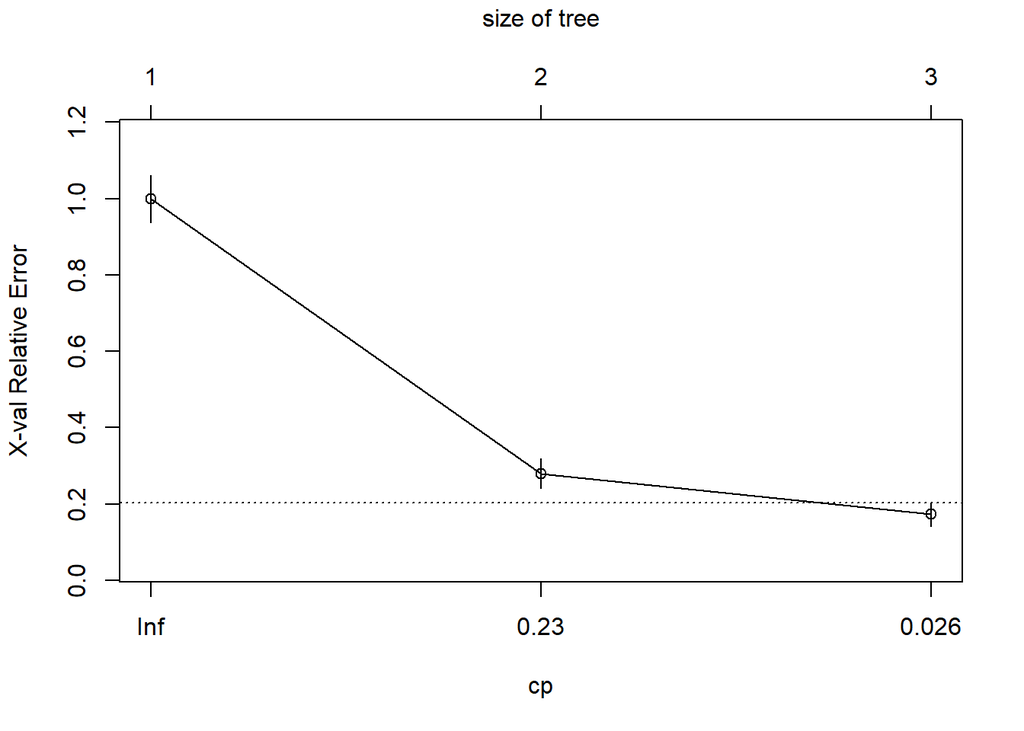

```r
plotcp(tree_model)  # visualizes error vs. tree size; look for the "elbow"
```

```r
# Standard rule of thumb: pick the cp with the lowest cross-validated
# error (xerror). which.min() finds that row automatically so this
# generalizes to any dataset without hand-reading the table above.
best_cp <- tree_model$cptable[which.min(tree_model$cptable[, "xerror"]), "CP"]
cat("Selected cp for pruning:", best_cp, "\n")
```

```
## Selected cp for pruning: 0.01
```

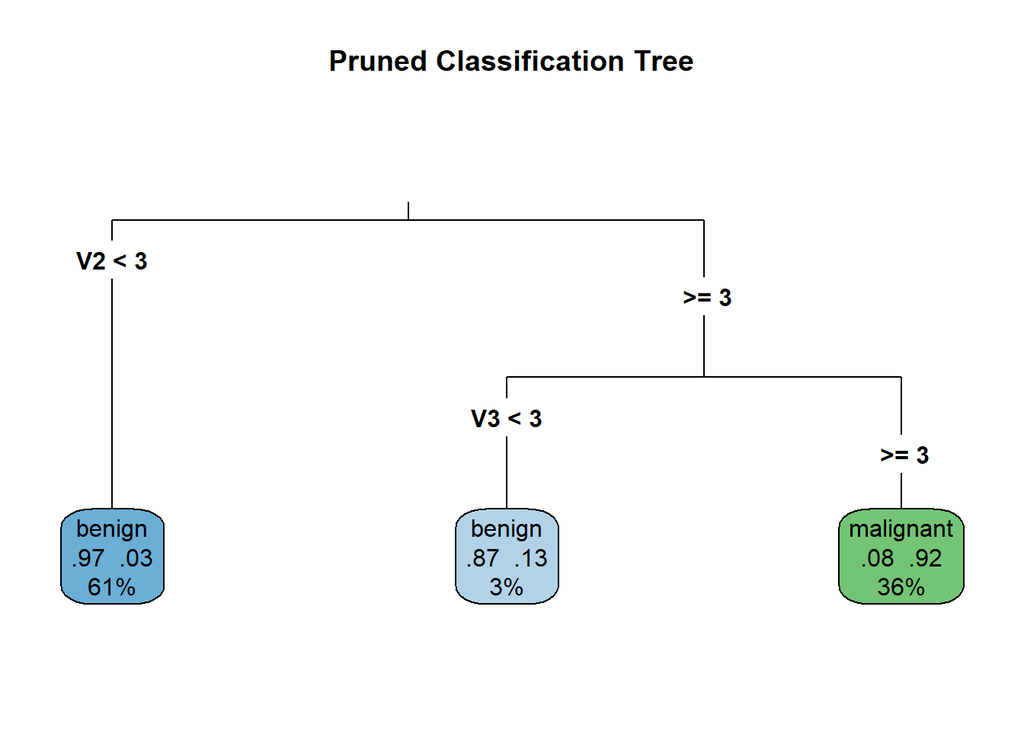

```r
pruned_tree <- prune(tree_model, cp = best_cp)

rpart.plot(
  pruned_tree,
  type = 3, extra = 104, fallen.leaves = TRUE,
  main = "Pruned Classification Tree",
  box.palette = "auto"
)
```

> **On this dataset:** with 9 correlated features and ~480 training rows, `biopsy` gives the pruning step more to actually do than `iris` did — watch `plotcp()` for whether the cross-validated error keeps dropping past the first split or plateaus early.

## 7.1 Predictions and Evaluation

```r
tree_preds <- predict(pruned_tree, newdata = test_data, type = "class")

# positive = "malignant": in a medical-diagnosis setting we care most about
# correctly flagging the malignant (positive) cases, so we tell caret which
# level to treat as "positive" for Sensitivity/Specificity, rather than
# letting it default to the alphabetically-first level ("benign").
tree_cm <- confusionMatrix(tree_preds, test_data$class, positive = "malignant")
tree_cm
```

```
## Confusion Matrix and Statistics
##
##            Reference
## Prediction  benign malignant
##   benign       127         6
##   malignant      6        65
##
##                Accuracy : 0.9412
##                  95% CI : (0.8995, 0.9692)
##     No Information Rate : 0.652
##     P-Value [Acc > NIR] : <2e-16
##
##                   Kappa : 0.8704
##
##  Mcnemar's Test P-Value : 1
##
##             Sensitivity : 0.9155
##             Specificity : 0.9549
##          Pos Pred Value : 0.9155
##          Neg Pred Value : 0.9549
##              Prevalence : 0.3480
##          Detection Rate : 0.3186
##    Detection Prevalence : 0.3480
##       Balanced Accuracy : 0.9352
##
##        'Positive' Class : malignant
##
```

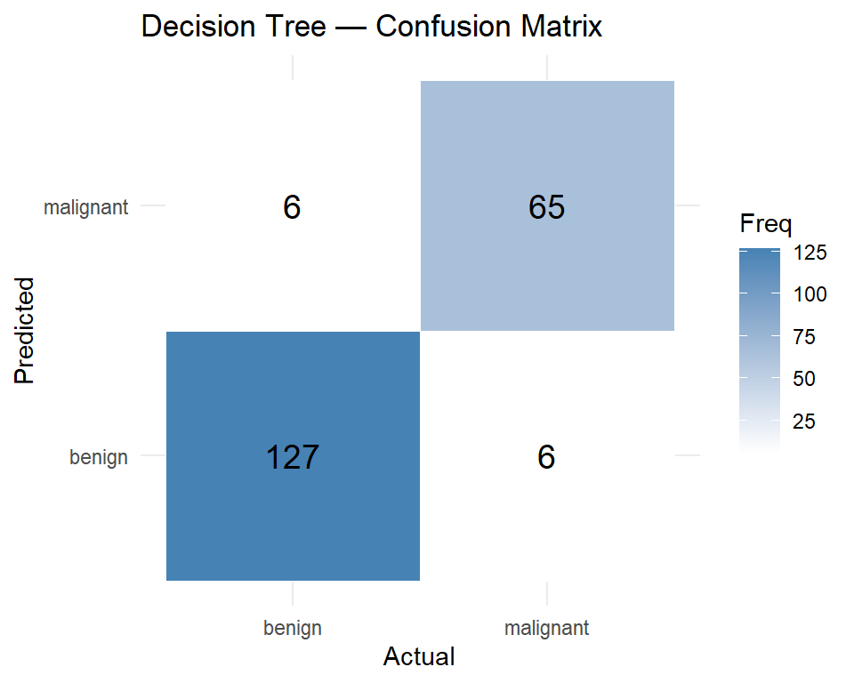

```r
as.data.frame(tree_cm$table) %>%
  ggplot(aes(x = Reference, y = Prediction, fill = Freq)) +
  geom_tile(color = "white") +
  geom_text(aes(label = Freq), size = 5) +
  scale_fill_gradient(low = "white", high = "steelblue") +
  labs(title = "Decision Tree — Confusion Matrix", x = "Actual", y = "Predicted") +
  theme_minimal()
```

# 8. k-Nearest Neighbors (KNN)

## 8.1 Feature Scaling

```r
# --------------------------------------------------------------------
# IMPORTANT: we compute the scaling parameters (mean, sd) from the
# TRAINING set only, then apply that SAME transformation to the test set,
# to avoid leaking test-set information into training.
# --------------------------------------------------------------------
feature_cols <- c("V1", "V2", "V3", "V4", "V5", "V6", "V7", "V8", "V9")

preproc <- preProcess(train_data[, feature_cols], method = c("center", "scale"))

train_scaled <- predict(preproc, train_data[, feature_cols])
test_scaled  <- predict(preproc, test_data[, feature_cols])

# Labels are kept separately, since knn() takes them as their own argument
train_labels <- train_data$class
test_labels  <- test_data$class

summary(train_scaled)  # each feature should now have mean ~0, sd ~1
```

```
##        V1                V2                V3                V4
##  Min.   :-1.2359   Min.   :-0.6951   Min.   :-0.7489   Min.   :-0.6404
##  1st Qu.:-0.8844   1st Qu.:-0.6951   1st Qu.:-0.7489   1st Qu.:-0.6404
##  Median :-0.1813   Median :-0.6951   Median :-0.7489   Median :-0.6404
##  Mean   : 0.0000   Mean   : 0.0000   Mean   : 0.0000   Mean   : 0.0000
##  3rd Qu.: 0.5218   3rd Qu.: 0.6209   3rd Qu.: 0.5933   3rd Qu.: 0.4347
##  Max.   : 1.9280   Max.   : 2.2660   Max.   : 2.2711   Max.   : 2.5848
##        V5                V6                V7                V8
##  Min.   :-0.9908   Min.   :-0.7122   Min.   :-1.0028   Min.   :-0.6216
##  1st Qu.:-0.5435   1st Qu.:-0.7122   1st Qu.:-0.5905   1st Qu.:-0.6216
##  Median :-0.5435   Median :-0.7122   Median :-0.1782   Median :-0.6216
##  Mean   : 0.0000   Mean   : 0.0000   Mean   : 0.0000   Mean   : 0.0000
##  3rd Qu.: 0.3511   3rd Qu.: 0.9345   3rd Qu.: 0.6465   3rd Qu.: 0.3632
##  Max.   : 3.0351   Max.   : 1.7579   Max.   : 2.7081   Max.   : 2.3329
##        V9
##  Min.   :-0.3411
##  1st Qu.:-0.3411
##  Median :-0.3411
##  Mean   : 0.0000
##  3rd Qu.:-0.3411
##  Max.   : 5.1458
```

## 8.2 Choosing *k*

```r
k_values <- 1:20

# For each candidate k, fit and evaluate a KNN model, storing accuracy
accuracy_by_k <- map_dbl(k_values, function(k) {
  pred <- knn(train = train_scaled, test = test_scaled,
              cl = train_labels, k = k)
  mean(pred == test_labels)
})

k_results <- tibble(k = k_values, accuracy = accuracy_by_k)
best_k <- k_results$k[which.max(k_results$accuracy)]

cat("Best k (by test accuracy):", best_k, "\n")
```

```
## Best k (by test accuracy): 3
```

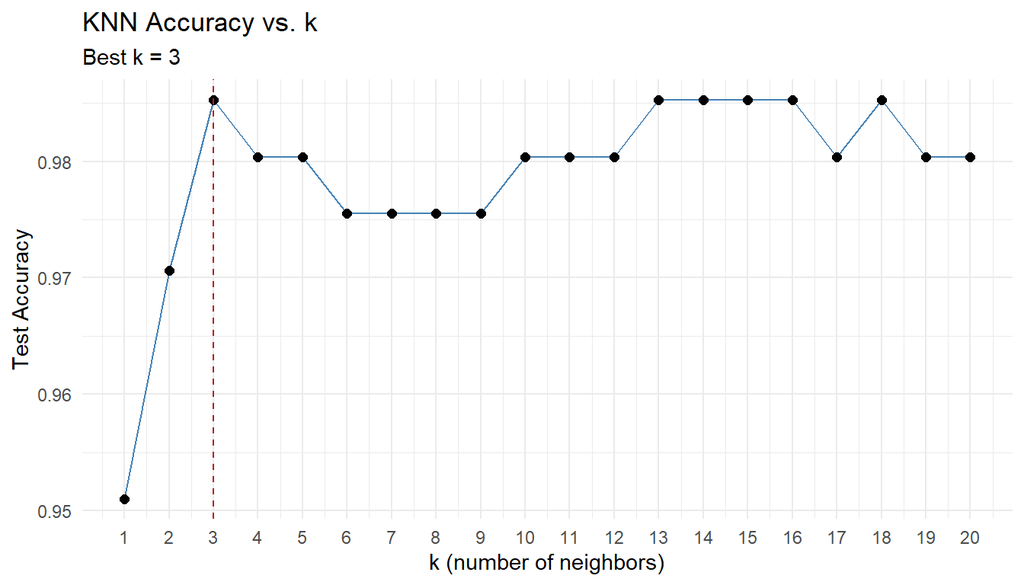

```r
ggplot(k_results, aes(x = k, y = accuracy)) +
  geom_line(color = "steelblue") +
  geom_point(size = 2) +
  geom_vline(xintercept = best_k, linetype = "dashed", color = "firebrick") +
  scale_x_continuous(breaks = k_values) +
  labs(title = "KNN Accuracy vs. k",
       subtitle = paste("Best k =", best_k),
       x = "k (number of neighbors)", y = "Test Accuracy") +
  theme_minimal()
```

> **Same methodological caveat as before:** selecting *k* by directly maximizing test-set accuracy risks mild overfitting to the test set. Section 8.4 repeats the more rigorous cross-validated approach.

## 8.3 Final KNN Model and Evaluation

```r
knn_preds <- knn(train = train_scaled, test = test_scaled,
                  cl = train_labels, k = best_k)

knn_cm <- confusionMatrix(knn_preds, test_labels, positive = "malignant")
knn_cm
```

```
## Confusion Matrix and Statistics
##
##            Reference
## Prediction  benign malignant
##   benign       133         3
##   malignant      0        68
##
##                Accuracy : 0.9853
##                  95% CI : (0.9576, 0.997)
##     No Information Rate : 0.652
##     P-Value [Acc > NIR] : <2e-16
##
##                   Kappa : 0.9673
##
##  Mcnemar's Test P-Value : 0.2482
##
##             Sensitivity : 0.9577
##             Specificity : 1.0000
##          Pos Pred Value : 1.0000
##          Neg Pred Value : 0.9779
##              Prevalence : 0.3480
##          Detection Rate : 0.3333
##    Detection Prevalence : 0.3333
##       Balanced Accuracy : 0.9789
##
##        'Positive' Class : malignant
##
```

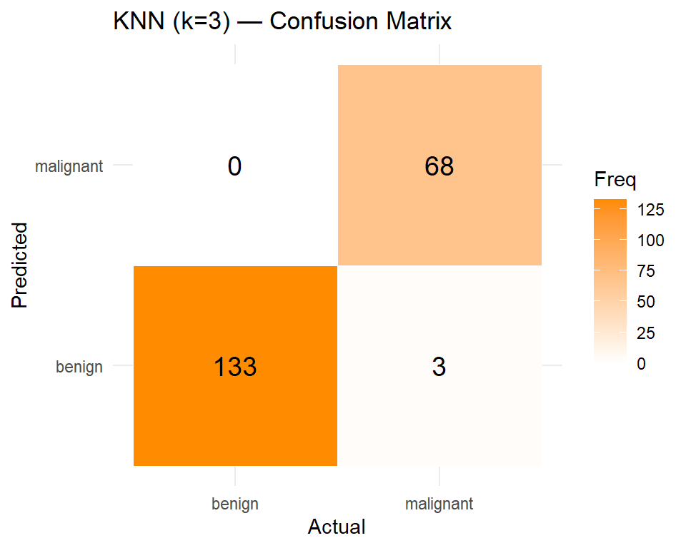

```r
as.data.frame(knn_cm$table) %>%
  ggplot(aes(x = Reference, y = Prediction, fill = Freq)) +
  geom_tile(color = "white") +
  geom_text(aes(label = Freq), size = 5) +
  scale_fill_gradient(low = "white", high = "darkorange") +
  labs(title = paste0("KNN (k=", best_k, ") — Confusion Matrix"),
       x = "Actual", y = "Predicted") +
  theme_minimal()
```

## 8.4 (Recommended) Cross-Validated KNN via `caret`

```r
ctrl <- trainControl(method = "cv", number = 10, classProbs = TRUE)

knn_cv_model <- train(
  class ~ V1 + V2 + V3 + V4 + V5 + V6 + V7 + V8 + V9,
  data = train_data,
  method = "knn",
  trControl = ctrl,
  preProcess = c("center", "scale"),   # scaling is applied inside each CV fold
  tuneGrid = expand.grid(k = 1:20)
)

knn_cv_model
```

```
## k-Nearest Neighbors
##
## 479 samples
##   9 predictor
##   2 classes: 'benign', 'malignant'
##
## Pre-processing: centered (9), scaled (9)
## Resampling: Cross-Validated (10 fold)
## Summary of sample sizes: 431, 431, 432, 431, 430, 432, ...
## Resampling results across tuning parameters:
##
##   k   Accuracy   Kappa
##    1  0.9561152  0.9031890
##    2  0.9519911  0.8941008
##    3  0.9602819  0.9120706
##    4  0.9560709  0.9030110
##    5  0.9623652  0.9166844
##    6  0.9582429  0.9079051
##    7  0.9624095  0.9166225
##    8  0.9644929  0.9216317
##    9  0.9624095  0.9170163
##   10  0.9624521  0.9170668
##   11  0.9644929  0.9216317
##   12  0.9624095  0.9176271
##   13  0.9624095  0.9173699
##   14  0.9624095  0.9176271
##   15  0.9603262  0.9131037
##   16  0.9644929  0.9225825
##   17  0.9582854  0.9087959
##   18  0.9582854  0.9087959
##   19  0.9582854  0.9087959
##   20  0.9603262  0.9133609
##
## Accuracy was used to select the optimal model using the largest value.
## The final value used for the model was k = 16.
```

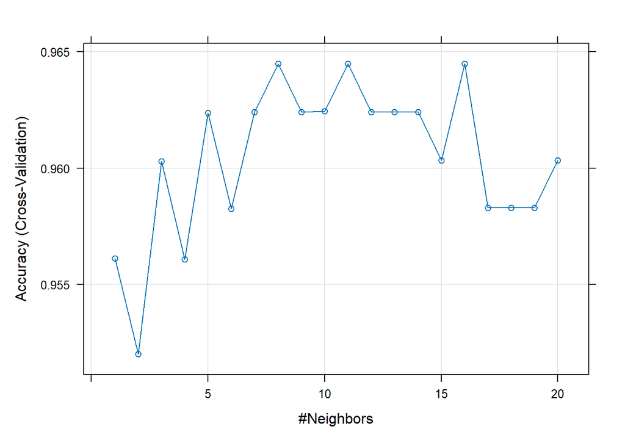

```r
plot(knn_cv_model)  # cross-validated accuracy vs. k
```

```r
# Evaluate the cross-validation-selected model once, on the held-out test set
knn_cv_preds <- predict(knn_cv_model, newdata = test_data)
knn_cv_cm <- confusionMatrix(knn_cv_preds, test_data$class, positive = "malignant")
knn_cv_cm
```

```
## Confusion Matrix and Statistics
##
##            Reference
## Prediction  benign malignant
##   benign       132         2
##   malignant      1        69
##
##                Accuracy : 0.9853
##                  95% CI : (0.9576, 0.997)
##     No Information Rate : 0.652
##     P-Value [Acc > NIR] : <2e-16
##
##                   Kappa : 0.9675
##
##  Mcnemar's Test P-Value : 1
##
##             Sensitivity : 0.9718
##             Specificity : 0.9925
##          Pos Pred Value : 0.9857
##          Neg Pred Value : 0.9851
##              Prevalence : 0.3480
##          Detection Rate : 0.3382
##    Detection Prevalence : 0.3431
##       Balanced Accuracy : 0.9822
##
##        'Positive' Class : malignant
##
```

# 9. Model Comparison

```r
comparison <- tibble(
  Model = c("Decision Tree (pruned)", "KNN (test-tuned)", "KNN (cross-validated)"),
  Accuracy = c(
    tree_cm$overall["Accuracy"],
    knn_cm$overall["Accuracy"],
    knn_cv_cm$overall["Accuracy"]
  ),
  Kappa = c(
    tree_cm$overall["Kappa"],
    knn_cm$overall["Kappa"],
    knn_cv_cm$overall["Kappa"]
  ),
  # Sensitivity for the "malignant" class matters most clinically here:
  # a false negative (calling a malignant tumor benign) is the costly error.
  Sensitivity_Malignant = c(
    tree_cm$byClass["Sensitivity"],
    knn_cm$byClass["Sensitivity"],
    knn_cv_cm$byClass["Sensitivity"]
  ),
  Specificity_Benign = c(
    tree_cm$byClass["Specificity"],
    knn_cm$byClass["Specificity"],
    knn_cv_cm$byClass["Specificity"]
  )
)

comparison
```

```
## # A tibble: 3 × 5
##   Model                  Accuracy Kappa Sensitivity_Malignant Specificity_Benign
##   <chr>                     <dbl> <dbl>                 <dbl>              <dbl>
## 1 Decision Tree (pruned)    0.941 0.870                 0.915              0.955
## 2 KNN (test-tuned)          0.985 0.967                 0.958              1
## 3 KNN (cross-validated)     0.985 0.967                 0.972              0.992
```

| Aspect | Decision Tree | KNN |
| --- | --- | --- |
| **How it decides** | Learns explicit if–then split rules | Majority vote among *k* nearest points |
| **Feature scaling required?** | No | **Yes** — critical |
| **Interpretability** | High — the tree itself is the explanation | Low — no explicit model to inspect |
| **Handles correlated features** | Naturally — picks one, ignores redundant ones | Uses all of them in every distance calculation |
| **Sensitive to** | Overfitting if unpruned | Choice of *k*; irrelevant/unscaled features; class imbalance |
| **Decision boundary shape** | Axis-aligned rectangles | Arbitrarily shaped, locally adaptive |

> **On `biopsy` vs. `iris`:** both models still perform well here (breast biopsy features are strongly diagnostic), but accuracy alone hides more than it did with iris’s 3 well-separated classes. Because the classes are imbalanced (~65/35) and errors are asymmetric, the **sensitivity for the malignant class** in the table above is the number worth scrutinizing most — a model with high overall accuracy but lower malignant-class sensitivity is quietly missing real cancers.

## 9.1 Bonus: ROC / AUC

Because `biopsy` is binary (unlike iris’s 3 classes), ROC/AUC analysis is directly applicable without a one-vs-rest workaround — this was flagged as a “next step” in the iris version, and it’s straightforward to add here.

```r
# Class probabilities (not just hard class labels) are needed for ROC curves
tree_probs   <- predict(pruned_tree, newdata = test_data, type = "prob")[, "malignant"]
knn_cv_probs <- predict(knn_cv_model, newdata = test_data, type = "prob")[, "malignant"]

roc_tree <- roc(test_data$class, tree_probs, levels = c("benign", "malignant"))
roc_knn  <- roc(test_data$class, knn_cv_probs, levels = c("benign", "malignant"))

cat("Decision Tree AUC:", round(auc(roc_tree), 3), "\n")
```

```
## Decision Tree AUC: 0.954
```

```r
cat("KNN (cross-validated) AUC:", round(auc(roc_knn), 3), "\n")
```

```
## KNN (cross-validated) AUC: 0.992
```

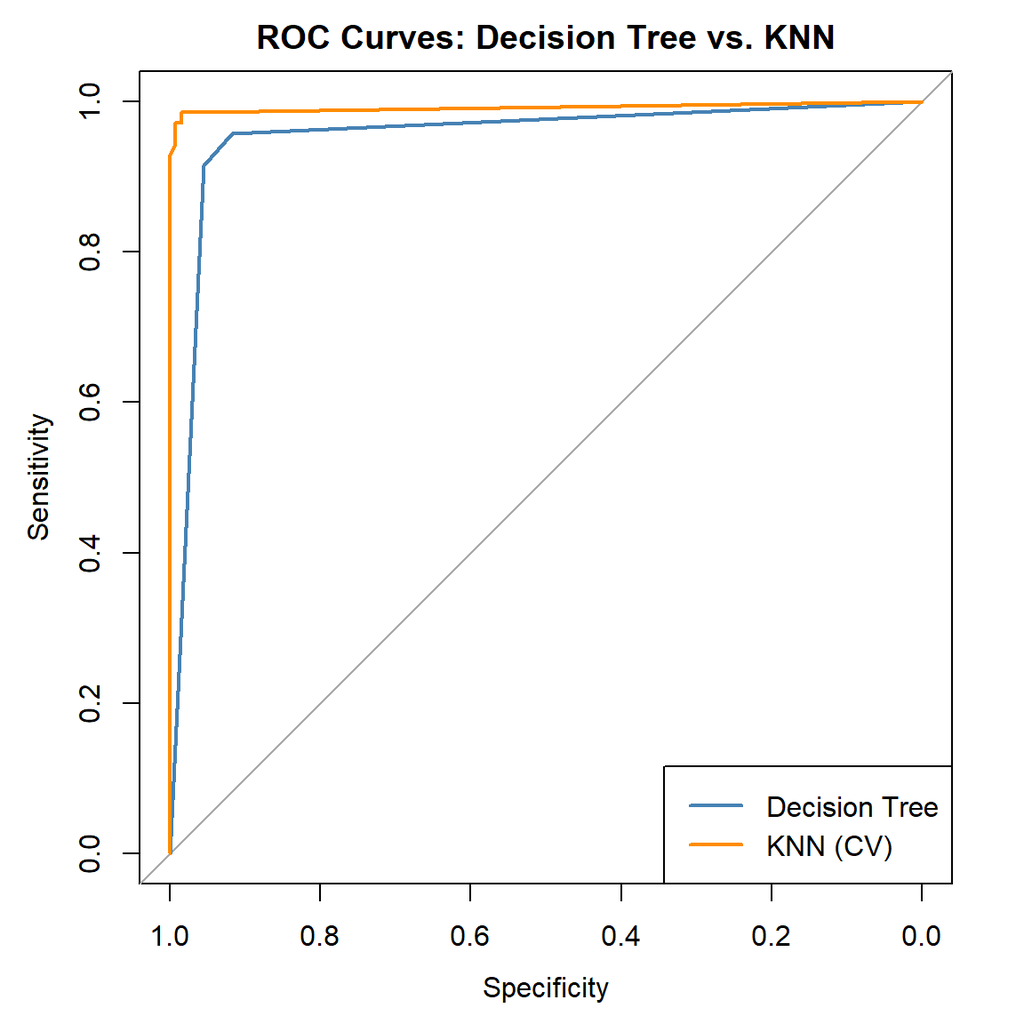

```r
plot(roc_tree, col = "steelblue", main = "ROC Curves: Decision Tree vs. KNN")
plot(roc_knn, col = "darkorange", add = TRUE)
legend("bottomright", legend = c("Decision Tree", "KNN (CV)"),
       col = c("steelblue", "darkorange"), lwd = 2)
```

# 10. Save Outputs

```r
# Predictions and confusion matrices, for reuse in a report or paper
write_csv(
  test_data %>%
    mutate(Tree_Prediction = tree_preds, KNN_Prediction = knn_preds),
  "biopsy_test_predictions.csv"
)

write_csv(comparison, "biopsy_model_comparison.csv")
write_csv(k_results, "biopsy_knn_accuracy_by_k.csv")

# Save key plots
ggsave("biopsy_decision_tree_plot.png", plot = last_plot(), width = 7, height = 6, dpi = 300)
ggsave("biopsy_knn_accuracy_vs_k.png",
       plot = ggplot(k_results, aes(x = k, y = accuracy)) +
         geom_line(color = "steelblue") + geom_point() + theme_minimal(),
       width = 7, height = 4, dpi = 300)

cat("Saved files: biopsy_test_predictions.csv, biopsy_model_comparison.csv,",
    "biopsy_knn_accuracy_by_k.csv, biopsy_decision_tree_plot.png,",
    "biopsy_knn_accuracy_vs_k.png\n")
```

```
## Saved files: biopsy_test_predictions.csv, biopsy_model_comparison.csv, biopsy_knn_accuracy_by_k.csv, biopsy_decision_tree_plot.png, biopsy_knn_accuracy_vs_k.png
```

# 11. Summary